# chapter 4

## Linear transformations

Do not affect the fit, or predictions, of a classical regeression model - but in a multilevel they can! They can improve interpretability though.

```
## lm(formula = earn ~ height)
##             coef.est  coef.se
## (Intercept) -61316.28   9525.18
## height        1262.33    142.11
## ---
## n = 1192, k = 2
## residual sd = 18865.08, R-Squared = 0.06
```

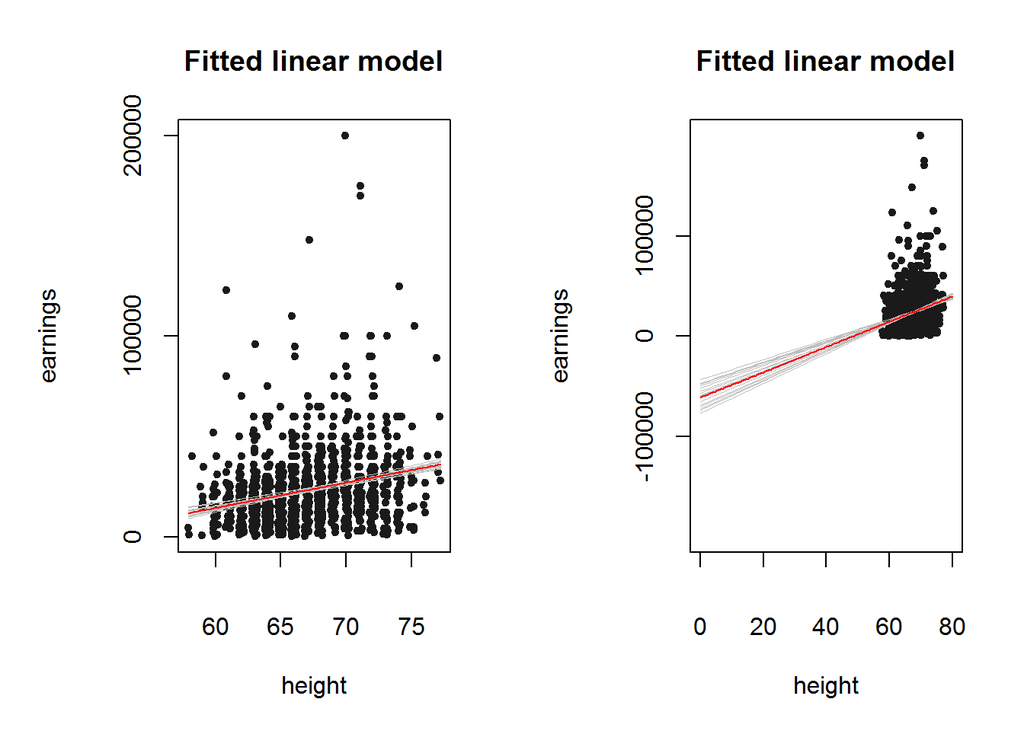

## Centering and standardizing, especially models with interacitons

From chapter 3 we had the kids score model with the mom hs and iq interaciton.

```r
kidiq <- read.dta("../data/child.iq/kidiq.dta")
attach(kidiq)
fit.4 <- lm (kid_score ~ mom_hs + mom_iq + mom_hs*mom_iq)
display(fit.4)
```

```
## lm(formula = kid_score ~ mom_hs + mom_iq + mom_hs * mom_iq)
##               coef.est coef.se
## (Intercept)   -11.48    13.76
## mom_hs         51.27    15.34
## mom_iq          0.97     0.15
## mom_hs:mom_iq  -0.48     0.16
## ---
## n = 434, k = 4
## residual sd = 17.97, R-Squared = 0.23
```

```r
 # centering by subtracting the mean
c_mom_hs <- mom_hs - mean(mom_hs)
c_mom_iq <- mom_iq - mean(mom_iq)

fit.5 <- lm (kid_score ~ c_mom_hs + c_mom_iq + c_mom_hs:c_mom_iq)
display(fit.5)
```

```
## lm(formula = kid_score ~ c_mom_hs + c_mom_iq + c_mom_hs:c_mom_iq)
##                   coef.est coef.se
## (Intercept)       87.64     0.91
## c_mom_hs           2.84     2.43
## c_mom_iq           0.59     0.06
## c_mom_hs:c_mom_iq -0.48     0.16
## ---
## n = 434, k = 4
## residual sd = 17.97, R-Squared = 0.23
```

First one is difficult to interpret, since the 51.27 coefficient e.g. applies to those with mom-iq = 0, which doesn’t happen. So instead we can center the predictors on the mean, and so in the second regression we can interpret them relative to the mean of the data.

So now a change of mom_hs of one (that is having completed highschool) is related to a child’s score increase of 2.84 among those with an average mom IQ of 100.

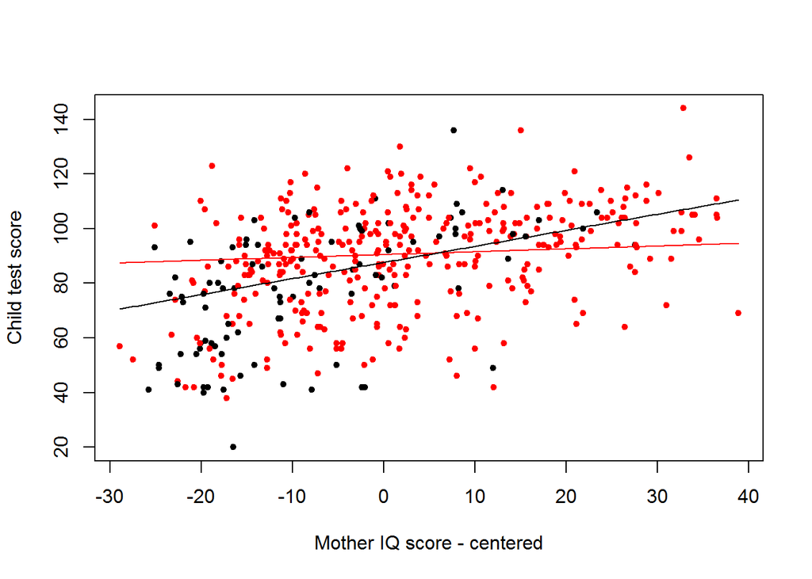

```r
## Figure 4.1 (right)
par(mfrow = c(1,1))
plot(c_mom_iq,kid_score, xlab="Mother IQ score - centered",
  ylab="Child test score",pch=20, xaxt="n", yaxt="n", col= mom_hs+1)
curve(cbind(1,1,x,1*x) %*% coef(fit.5), col = 2, add = TRUE)
curve(cbind(1,0,x,0*x) %*% coef(fit.5), col = 1, add = TRUE)
axis(1)
axis(2)
```

Another option is to center on an understandable reference point, for example the midpoint of the range.

```r
c2_mom_hs <- mom_hs - 0.5
c2_mom_iq <- mom_iq - 100
fit.6 <- lm (kid_score ~ c2_mom_hs + c2_mom_iq + c2_mom_hs:c2_mom_iq)
display(fit.6)
```

```
## lm(formula = kid_score ~ c2_mom_hs + c2_mom_iq + c2_mom_hs:c2_mom_iq)
##                     coef.est coef.se
## (Intercept)         86.83     1.21
## c2_mom_hs            2.84     2.43
## c2_mom_iq            0.73     0.08
## c2_mom_hs:c2_mom_iq -0.48     0.16
## ---
## n = 434, k = 4
## residual sd = 17.97, R-Squared = 0.23
```

So centering helps interpret the main effects sensibly, but there’s still the scaling problem. mom_hs beta is much larger than mom_iq beta, but that’s misleading. Then you can also do a z-score standardization, OR, subtract the mean and divide by 2 standard deviations, which is what Gelman et al do instead.

```r
c3_mom_hs <- (mom_hs - mean(mom_hs))/(2*sd(mom_hs))
c3_mom_iq <-  (mom_iq - mean(mom_iq))/(2*sd(mom_iq))
fit.7 <- lm (kid_score ~ c3_mom_hs + c3_mom_iq + c3_mom_hs:c3_mom_iq)
display(fit.7)
```

```
## lm(formula = kid_score ~ c3_mom_hs + c3_mom_iq + c3_mom_hs:c3_mom_iq)
##                     coef.est coef.se
## (Intercept)          87.64     0.91
## c3_mom_hs             2.33     1.99
## c3_mom_iq            17.65     1.82
## c3_mom_hs:c3_mom_iq -11.94     4.00
## ---
## n = 434, k = 4
## residual sd = 17.97, R-Squared = 0.23
```

But the point is that if you divide by 2 sd then you don’t need to divide the binary, just subtract the mean, although I’m not clear why you wouldn’t divide the binary as well, since it’s easy to do - and this isn’t precise?

```r
c4_mom_hs <- mom_hs - mean(mom_hs)
c4_mom_iq <-  (mom_iq - mean(mom_iq))/(2*sd(mom_iq))
fit.8 <- lm (kid_score ~ c4_mom_hs + c4_mom_iq + c4_mom_hs:c4_mom_iq)
display(fit.8)
```

```
## lm(formula = kid_score ~ c4_mom_hs + c4_mom_iq + c4_mom_hs:c4_mom_iq)
##                     coef.est coef.se
## (Intercept)          87.64     0.91
## c4_mom_hs             2.84     2.43
## c4_mom_iq            17.65     1.82
## c4_mom_hs:c4_mom_iq -14.53     4.87
## ---
## n = 434, k = 4
## residual sd = 17.97, R-Squared = 0.23
```

## Correlation and regression to the mean

If you have a simple single predictor regression, and both x and y are standardized, then the intercept is zero and the slope is the correlation between them.

```r
# from https://stats.stackexchange.com/questions/15011/generate-a-random-variable-with-a-defined-correlation-to-an-existing-variable
# how to get simulated data with a specific correlation
n     <- 100                   # length of vector
rho   <- 0.5                  # desired correlation = cos(angle)
theta <- acos(rho)             # corresponding angle
x1    <- rnorm(n )        # fixed given data
x2    <- rnorm(n)      # new random data
X     <- cbind(x1, x2)         # matrix
Xctr  <- scale(X, center=TRUE, scale=FALSE)   # centered columns (mean 0)

Id   <- diag(n)                               # identity matrix
Q    <- qr.Q(qr(Xctr[ , 1, drop=FALSE]))      # QR-decomposition, just matrix Q
P    <- tcrossprod(Q)          # = Q Q'       # projection onto space defined by x1
x2o  <- (Id-P) %*% Xctr[ , 2]                 # x2ctr made orthogonal to x1ctr
Xc2  <- cbind(Xctr[ , 1], x2o)                # bind to matrix
Y    <- Xc2 %*% diag(1/sqrt(colSums(Xc2^2)))  # scale columns to length 1

y <- Y[ , 2] + (1 / tan(theta)) * Y[ , 1]     # final new vector
cor(x1, y)
```

```
## [1] 0.5
```

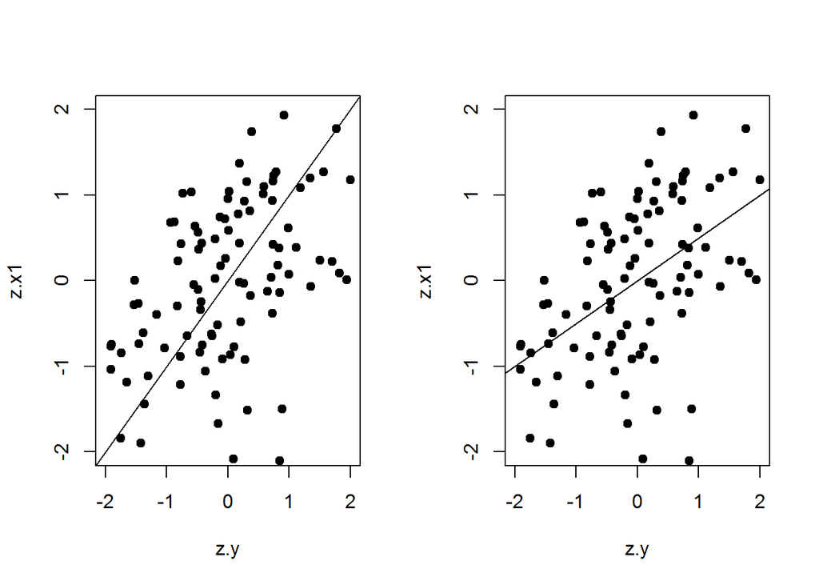

```r
z.y <- (y-mean(y))/sd(y)
z.x1 <- (x1-mean(x1))/sd(x1)
par(mfrow = c(1,2))
plot(z.y,z.x1, xlim = c(-2,2), ylim = c(-2,2), pch = 19)
abline(a =0, b = 1)
plot(z.y,z.x1, xlim = c(-2,2), ylim = c(-2,2), pch = 19)
abline(lm(z.y~z.x1))
```

```r
display(lm(z.y~z.x1))
```

```
## lm(formula = z.y ~ z.x1)
##             coef.est coef.se
## (Intercept) 0.00     0.09
## z.x1        0.50     0.09
## ---
## n = 100, k = 2
## residual sd = 0.87, R-Squared = 0.25
```

## Logarighmic transformations

“When additivity and linearity are not reasonable assumptions a nonlinear transformation can sometimes remedy the situation.”

- if the outcome is all positive then taking the logarithm makes sense, because it ensures the predictiins are always positive.
- A linear mode on the logarithmic scale also corresponds to a multiplicative model on the original scale!

```r
log.earn <- log(earn)
earn.logmodel.1 <- lm(log.earn ~ height)
display(earn.logmodel.1)
```

```
## lm(formula = log.earn ~ height)
##             coef.est coef.se
## (Intercept) 5.78     0.45
## height      0.06     0.01
## ---
## n = 1192, k = 2
## residual sd = 0.89, R-Squared = 0.06
```

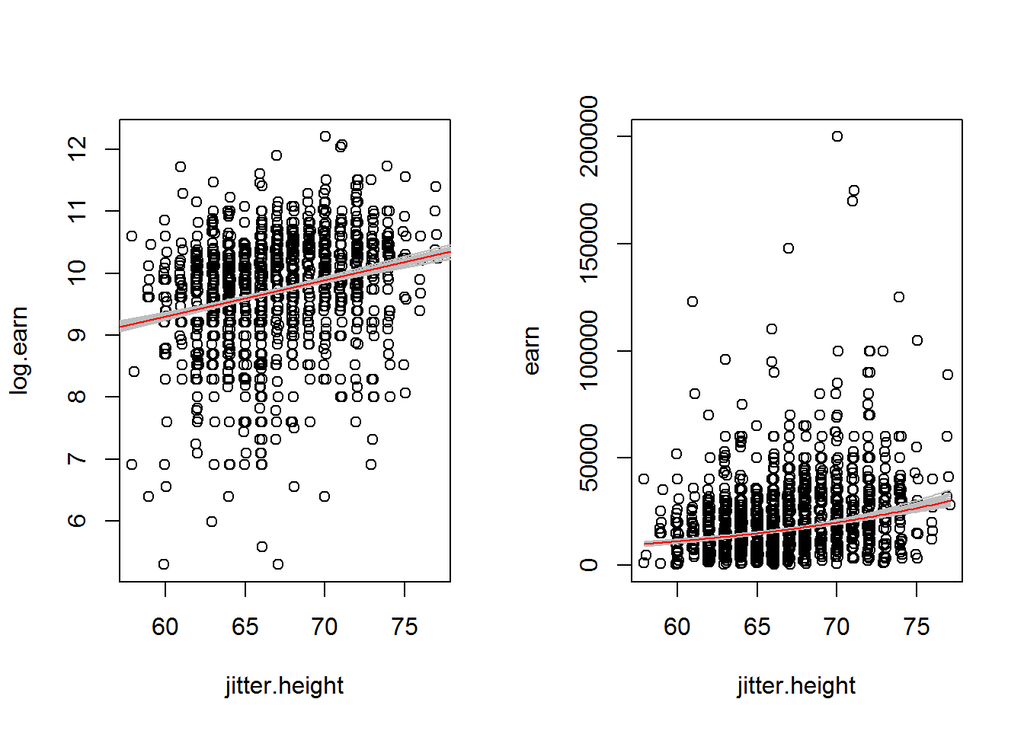

```r
jitter.height <-height +runif(length(height), -0.1, 0.1)
par(mfrow = c(1,2))
plot(log.earn ~ (jitter.height))
simz <- sim(earn.logmodel.1)
for (i in 1:25){
  abline(simz@coef[i,], col = "gray")}
abline(earn.logmodel.1, col = "red")
plot(earn ~ jitter.height)
simz <- sim(earn.logmodel.1)
for (i in 1:25){
  curve(exp(simz@coef[i,1]+simz@coef[i,2]*x),
        add = TRUE, col = "gray")}
curve(exp(coef(earn.logmodel.1)[1]+coef(earn.logmodel.1)[2]*x), add = TRUE, col = "red")
```

Interesting reason for using natural log scales: “because coefficients are then directly interpretable as apporximate proportional differences.” in this example the coefficient of 0.06 meant that one unit increase in height meant approximately 6% increase in earnings $e^{0.06}=$ 1.0618365. But this only applies to small coefficients!

### Now let’s add another predictor

```r
earn.logmodel.2 <- lm(log.earn ~ height + male)
display(earn.logmodel.2)
```

```
## lm(formula = log.earn ~ height + male)
##             coef.est coef.se
## (Intercept) 8.15     0.60
## height      0.02     0.01
## male        0.42     0.07
## ---
## n = 1192, k = 3
## residual sd = 0.88, R-Squared = 0.09
```

After controling for sex, one inch in height corresponds to approx 2% higher earnings.

Gender however has a massive impact: $e^{0.42}=$ 1.5219616.so that’s a 52 % higher predicted earnings for a man than for a woman of the same height.

### And an interaction term as well

```r
earn.logmodel.3 <- lm(log.earn ~ height + male + height:male)
display(earn.logmodel.3, digits=3)
```

```
## lm(formula = log.earn ~ height + male + height:male)
##             coef.est coef.se
## (Intercept)  8.388    0.844
## height       0.017    0.013
## male        -0.079    1.258
## height:male  0.007    0.019
## ---
## n = 1192, k = 4
## residual sd = 0.881, R-Squared = 0.09
```

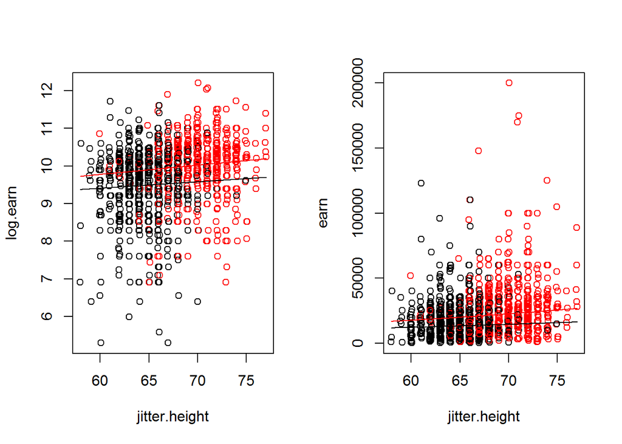

```r
jitter.height <-height +runif(length(height), -0.1, 0.1)
par(mfrow = c(1,2))
plot(log.earn ~ (jitter.height), col= male+1)

curve(coef(earn.logmodel.3)[1]+coef(earn.logmodel.3)[2]*x, add = TRUE, col = "black") # male = 0
curve(coef(earn.logmodel.3)[1]+coef(earn.logmodel.3)[2]*x
      +coef(earn.logmodel.3)[3]+coef(earn.logmodel.3)[4]*x, add = TRUE, col = "red") # male = 1

plot(earn ~ (jitter.height), col= male+1)
curve(exp(coef(earn.logmodel.3)[1]+coef(earn.logmodel.3)[2]*x), add = TRUE, col = "black") # male = 0
curve(exp(coef(earn.logmodel.3)[1]+coef(earn.logmodel.3)[2]*x
      +coef(earn.logmodel.3)[3]+coef(earn.logmodel.3)[4]*x), add = TRUE, col = "red") # male = 1
```

### But let’s transform the inputs to make the coefficients interpretable instead

Well this is kind of silly, he does the whole 2 standard deviations thing before, why not now, especially since we have a binary variable as well. I’ll do it here though and compare:

```
## lm(formula = log.earn ~ z.height + male + z.height:male)
##               coef.est coef.se
## (Intercept)   9.53     0.05
## z.height      0.07     0.05
## male          0.42     0.07
## z.height:male 0.03     0.07
## ---
## n = 1192, k = 4
## residual sd = 0.88, R-Squared = 0.09
```

```
## lm(formula = log.earn ~ z2.height + male + z2.height:male)
##                coef.est coef.se
## (Intercept)    9.53     0.05
## z2.height      0.13     0.10
## male           0.42     0.07
## z2.height:male 0.06     0.14
## ---
## n = 1192, k = 4
## residual sd = 0.88, R-Squared = 0.09
```

### Log-log model

```r
log.height <- log(height)
earn.logmodel.6 <- lm(log.earn ~ log.height + male )
display(earn.logmodel.6, digits=3)
```

```
## lm(formula = log.earn ~ log.height + male)
##             coef.est coef.se
## (Intercept) 3.616    2.599
## log.height  1.409    0.624
## male        0.422    0.072
## ---
## n = 1192, k = 3
## residual sd = 0.881, R-Squared = 0.09
```

So a one percent increase in height predicts a 1.41% difference in earnings.

## Other transformations

- square root - compresses high values more mildly than the logarithm. But these lack easy interpretability. And it’s non-monotonic, so negative predictions get amplified positively.
- idiosyncratic transformations. e.g. actual earingins are either zero or some positive value. we could split the model into two, first logistic for yes/no earnings, and then log trasformed regression like above. or if you had assets instead, negative, zero, or positive. then you could do e.g. a discrete scale e.g. -1000,-100,0,100,1000:-2, -1,-,1,2.
- don’t discretize predictors from continuous variables (except to model non-linearity as we’ll see later) because you’re just loosing information this way.
- sometimes you can discretise if other transformations don’t seem appropriate. e.g. modelling age as generations in e.g. political preference modelling since generational effects seem like a reasonable pattern.
- index vs indicator variables. index divides the populaiton into categories. indicator is yes/no. So one index variable with three categories is transformed into 3 indicator variables. which you include in your regression affects interpretability.

*Indentifiability* of the model–its parameters can be estimated uniquely.

- Most familiar issue arises from colinearity: when there is a set of predictors with a linear combination that equals zero for all of the data
- e.g. if you include indicator variables (based on an index variable with $J$ values) you can only include $J-1$ of them. Otherwise they would be collinear with the constant term (which you could remove, but you can only do this once, so if you have several sets of indicator variables that would not be a solution.)

## Building regression models for prediction (not for causal inference though!)

### General principles

- include all input variables that for substantive reasons might be important to the outcome
- you don’t necessariliy need to include all of them separately, sometimes an average or sum score can be used as a single predictor
- inputs with large effects you should consider including an interaction as well.

Decision rules based on expected sign and significance (more than 2 standard errors from 0):

- not significant but has expected sign, keep it in
- not significant and wrong sign - consider removing it
- is significang and wrong sign - think hard! Try to include lurking variables
- is significant and correct sign, by all means keep it in!

*But the assumption is you thought long and hard about the relationships before fitting the model.*

```
## lm(formula = weight ~ diam1 + diam2 + canopy.height + total.height +
##     density + group)
##               coef.est coef.se
## (Intercept)   -728.59   147.16
## diam1          189.67   112.76
## diam2          371.46   124.38
## canopy.height  355.67   209.84
## total.height  -101.73   185.57
## density        131.25    34.36
## group         -363.30   100.18
## ---
## n = 46, k = 7
## residual sd = 268.96, R-Squared = 0.85
```

Then it might be more reasonable to have the effects be multiplicative rather than additive. And log both so they can be directly interpreted as percentages:

```r
fit.2 <- lm (log(weight) ~ log(diam1) + log(diam2) + log(canopy.height) + log(total.height) +
   log(density) + group)
display(fit.2)
```

```
## lm(formula = log(weight) ~ log(diam1) + log(diam2) + log(canopy.height) +
##     log(total.height) + log(density) + group)
##                    coef.est coef.se
## (Intercept)         5.35     0.17
## log(diam1)          0.39     0.28
## log(diam2)          1.15     0.21
## log(canopy.height)  0.37     0.28
## log(total.height)   0.39     0.31
## log(density)        0.11     0.12
## group              -0.58     0.13
## ---
## n = 46, k = 7
## residual sd = 0.33, R-Squared = 0.89
```

So an increase in canopy height of one percent increases leaf weight by (approximately) 0.37 %.

But we might want to start with a simpler model:

```r
canopy.volume <- diam1 * diam2 * canopy.height
fit.3 <- lm(log(weight) ~ log(canopy.volume) )
display(fit.3)
```

```
## lm(formula = log(weight) ~ log(canopy.volume))
##                    coef.est coef.se
## (Intercept)        5.17     0.08
## log(canopy.volume) 0.72     0.05
## ---
## n = 46, k = 2
## residual sd = 0.41, R-Squared = 0.80
```

“weight is therefore proportional to the volume to the 0.72nd power. It is perhaps surprising that the power is not closer to 1. The usual explanation is that there is variation in canopy.volume that is unrelated to the weight of the leaves, and this tends to attenuate the regression coefficient.

```r
canopy.area <- diam1 * diam2
canopy.shape <- diam1/diam2
fit.4 <- lm(log(weight) ~ log(canopy.volume) + log(canopy.area) + log(canopy.shape) +
              log(total.height) + log(density) + group)
display(fit.4)
```

```
## lm(formula = log(weight) ~ log(canopy.volume) + log(canopy.area) +
##     log(canopy.shape) + log(total.height) + log(density) + group)
##                    coef.est coef.se
## (Intercept)         5.35     0.17
## log(canopy.volume)  0.37     0.28
## log(canopy.area)    0.40     0.29
## log(canopy.shape)  -0.38     0.23
## log(total.height)   0.39     0.31
## log(density)        0.11     0.12
## group              -0.58     0.13
## ---
## n = 46, k = 7
## residual sd = 0.33, R-Squared = 0.89
```

This has the same fit as model 2, but the coefficients are easer to interpret.

```r
fit.5 <- lm(log(weight) ~ log(canopy.volume) + log(canopy.area) +
               group)
display(fit.5)
```

```
## lm(formula = log(weight) ~ log(canopy.volume) + log(canopy.area) +
##     group)
##                    coef.est coef.se
## (Intercept)         5.22     0.09
## log(canopy.volume)  0.61     0.19
## log(canopy.area)    0.29     0.24
## group              -0.53     0.12
## ---
## n = 46, k = 4
## residual sd = 0.34, R-Squared = 0.87
```

very similar to if you include height and shape as well. It would also be a good idea to include the group interactions, but with only 46 data points it is impossible ot estimate the interactions accurately - none are significant. In the end there is no clean way of choosing between the models..

But here is a visualisation of this model with canopy volume and area and group.

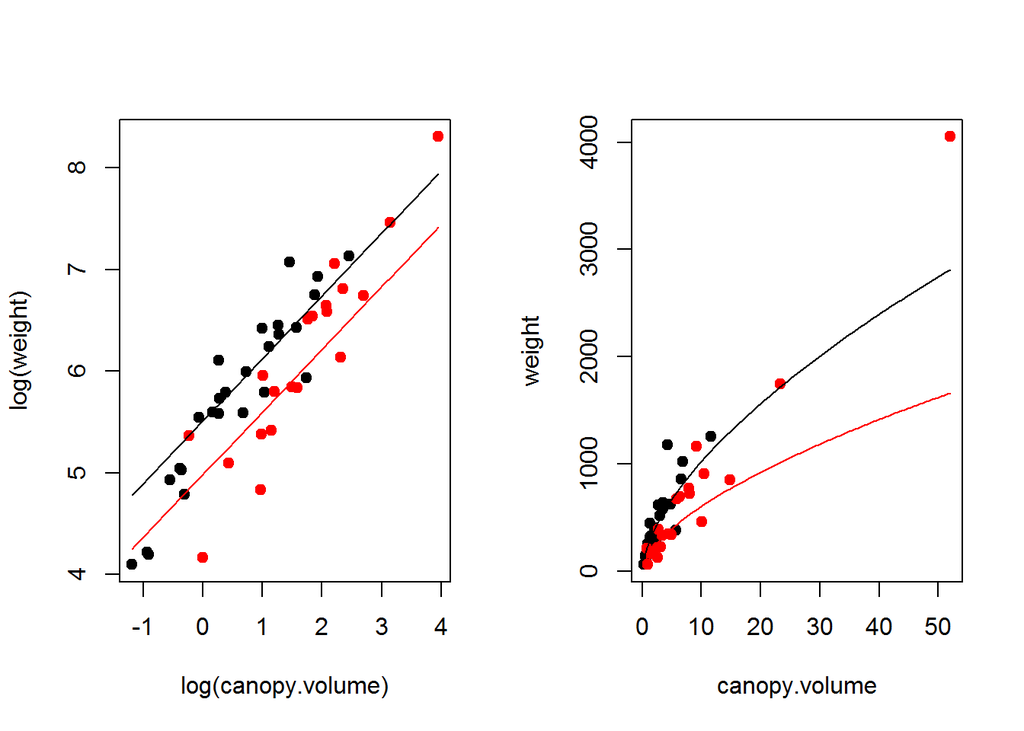

## Fitting a series of regressions

More informal than multilevel modelling - where you pool information on the paremeters of repeated regressions - but you can separately estimate the regression for each time period and display them together.

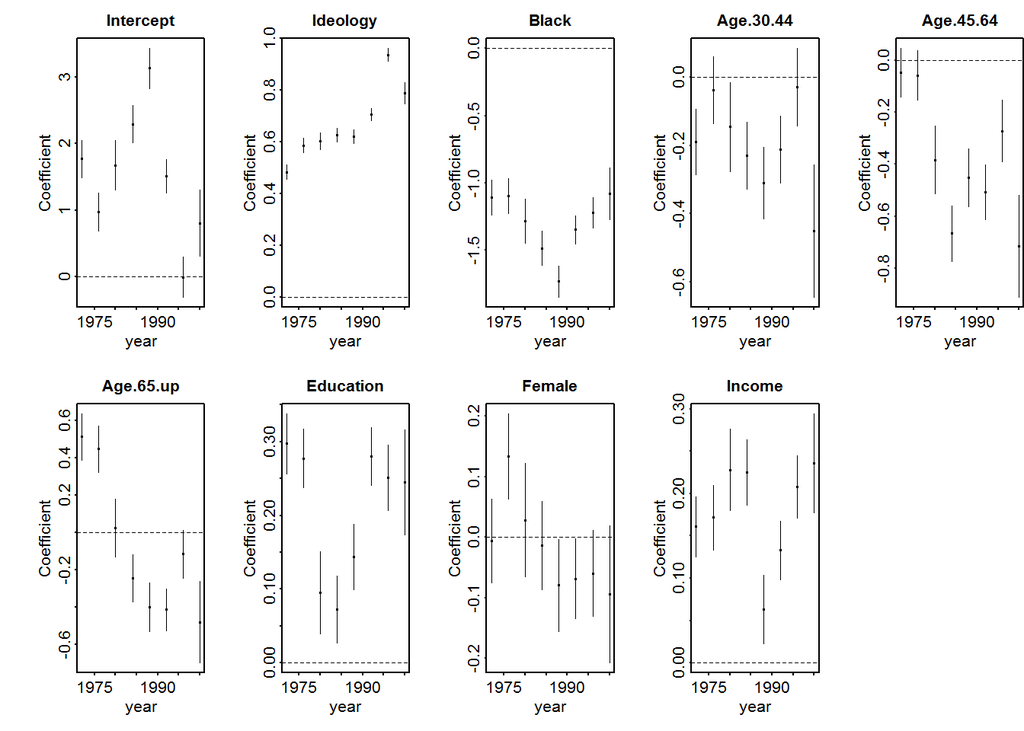

```r
brdata <- read.dta("../data/nes/nes5200_processed_voters_realideo.dta",convert.factors=F)
# Data are at http://www.stat.columbia.edu/~gelman/arm/examples/nes

 # Clean the data
brdata <- brdata[is.na(brdata$black)==FALSE&is.na(brdata$female)==FALSE&is.na(brdata$educ1)==FALSE
&is.na(brdata$age)==FALSE&is.na(brdata$income)==FALSE&is.na(brdata$state)==FALSE,]
kept.cases <- 1952:2000
matched.cases <- match(brdata$year, kept.cases)
keep <- !is.na(matched.cases)
data <- brdata[keep,]
plotyear <- unique(sort(data$year))
year.new <- match(data$year,unique(data$year))
n.year <- length(unique(data$year))
income.new <-data$income-3
age.new <- (data$age-mean(data$age))/10
y <- data$rep_pres_intent
data <- cbind(data, year.new, income.new, age.new, y)
nes.year <- data[,"year"]
age.discrete <- as.numeric (cut (data[,"age"], c(0,29.5, 44.5, 64.5, 200)))
race.adj <- ifelse (data[,"race"]>=3, 1.5, data[,"race"])
data <- cbind (data, age.discrete, race.adj)

female <- data[,"gender"] - 1
black <- ifelse (data[,"race"]==2, 1, 0)
rvote <- ifelse (data[,"presvote"]==1, 0, ifelse(data[,"presvote"]==2, 1, NA))

region.codes <- c(3,4,4,3,4,4,1,1,5,3,3,4,4,2,2,2,2,3,3,1,1,1,2,2,3,2,4,2,4,1,1,4,1,3,2,2,3,4,1,
   1,3,2,3,3,4,1,3,4,1,2,4)
attach(data)
 # Regression & plot

regress.year <- function (yr) {
  this.year <- data[nes.year==yr,]
  lm.0 <- lm (partyid7 ~ real_ideo + race.adj + factor(age.discrete) + educ1 + gender + income,
      data=this.year)
  coefs <- summary(lm.0)$coef[,1:2]
}

summary <- array (NA, c(9,2,8))
for (yr in seq(1972,2000,4)){
  i <- (yr-1968)/4
  summary[,,i] <- regress.year(yr)
}
yrs <- seq(1972,2000,4)
coef.names <- c("Intercept", "Ideology", "Black", "Age.30.44", "Age.45.64", "Age.65.up",
   "Education", "Female", "Income")

par (mfrow=c(2,5), mar=c(3,4,2,0))
for (k in 1:9){
  plot (range(yrs), range(0,summary[k,1,]+.67*summary[k,2,],summary[k,1,]-.67*summary[k,2,]),
     type="n", xlab="year", ylab="Coefficient", main=coef.names[k], mgp=c(1.2,.2,0), cex.main=1,
      cex.axis=1, cex.lab=1, tcl=-.1)
  abline (0,0,lwd=.5, lty=2)
  points (yrs, summary[k,1,], pch=20, cex=.5)
  segments (yrs, summary[k,1,]-.67*summary[k,2,], yrs, summary[k,1,]+.67*summary[k,2,], lwd=.5)
}
```

# Exercises

## 4.1

$log(weight) = -3.5 + 2.0 log(height) + error$ “errors have a standard deviation of 0.25”

Approx 68% of peole have weights within +/- 1.2840254 of the predicted values from the regression.

From https://github.com/IamGianluca/arm/blob/master/ch4/arm_ch4p1.md

```
## lm(formula = log.weights ~ log.heights)
##             coef.est coef.se
## (Intercept) -2.43     2.00
## log.heights  1.75     0.48
## ---
## n = 100, k = 2
## residual sd = 0.29, R-Squared = 0.12
```

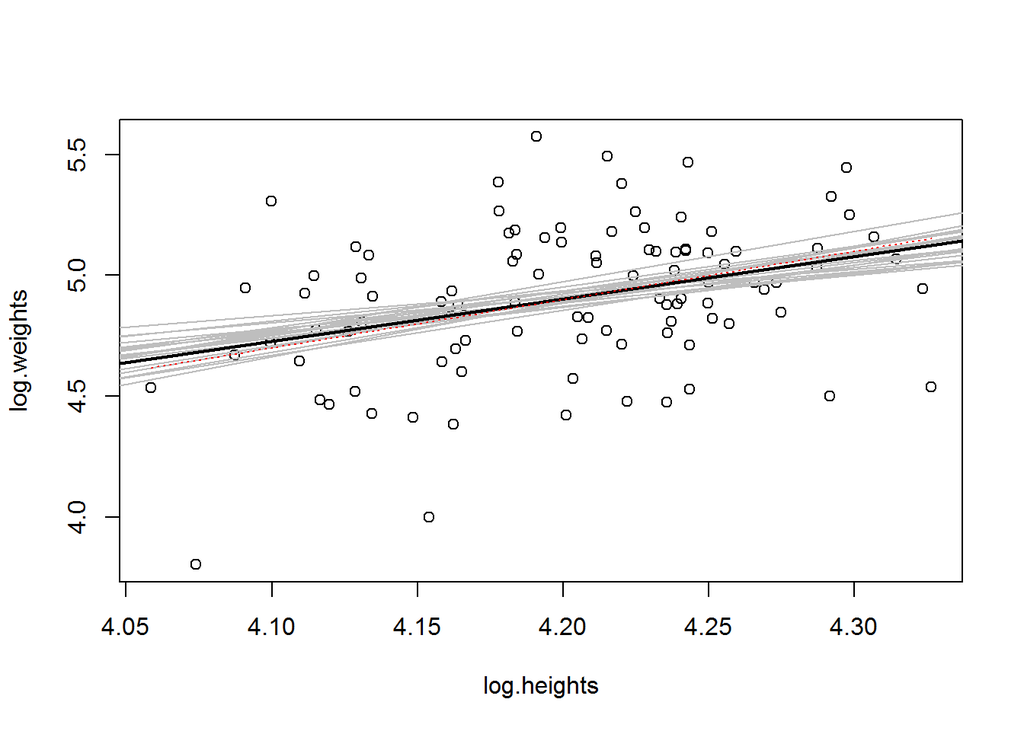

## 4.2

Didn’t really bother, there is no weight in the data..

```
##       earn            height           sex              ed
##  Min.   :   200   Min.   :58.00   Min.   :1.000   Min.   : 3.0
##  1st Qu.: 10000   1st Qu.:64.00   1st Qu.:1.000   1st Qu.:12.0
##  Median : 20000   Median :66.00   Median :2.000   Median :13.0
##  Mean   : 23155   Mean   :66.92   Mean   :1.576   Mean   :13.5
##  3rd Qu.: 30000   3rd Qu.:70.00   3rd Qu.:2.000   3rd Qu.:16.0
##  Max.   :200000   Max.   :77.00   Max.   :2.000   Max.   :18.0
##      yearbn
##  Min.   : 1.00
##  1st Qu.:39.75
##  Median :52.00
##  Mean   :48.87
##  3rd Qu.:61.00
##  Max.   :99.00
```

```
## lm(formula = log.earn ~ z.height + sex)
##             coef.est coef.se
## (Intercept)  9.71     0.03
## z.height     0.08     0.04
## sex         -0.42     0.07
## ---
## n = 1192, k = 3
## residual sd = 0.88, R-Squared = 0.09
```

```
## lm(formula = log.earn ~ z.height + sex + ed)
##             coef.est coef.se
## (Intercept)  8.12     0.14
## z.height     0.03     0.03
## sex         -0.47     0.07
## ed           0.12     0.01
## ---
## n = 1192, k = 4
## residual sd = 0.83, R-Squared = 0.18
```

## 4.3

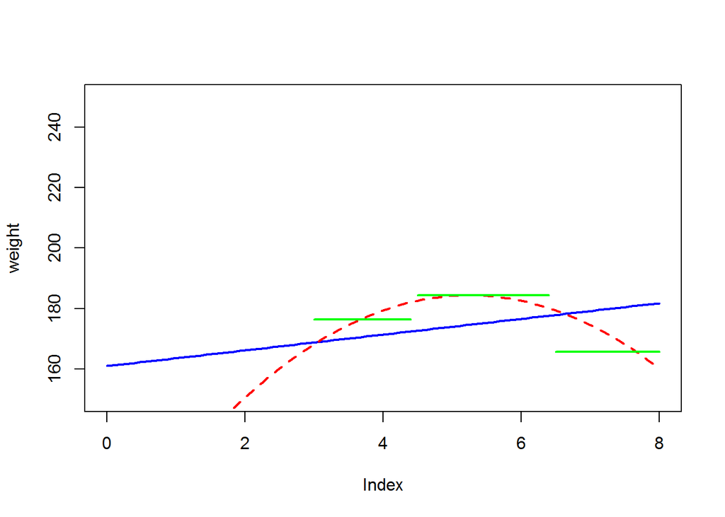